# Praca domowa 2

Imię Nazwisko - Tomasz Stolarczyk

## Dane

Dane wykorzystane w Pracy domowej 2 dotyczą wyników egzaminów z 3 umiejętności: czytania, pisania i operacji matematycznych. Dodatkowo dostępne są podstawowe informacje o studentach i ich rodzicach. Opis wszystkich kolumn znajduje się również w pliku `README.md`.

| Zmienna | Opis |
| --- | --- |
| **gender** | płeć |
| **race.ethnicity** | pochodzenie etniczne |
| **parental.level.of.education** | wykształcenie rodziców |
| **lunch** | jaki obiad jedli uczniowie w dniu egzaminu |
| **test.preparation.course** | czy uczeń odbył kurs przygotowujący |
| **math.score** | wynik egzaminu z matematyki |
| **reading.score** | wynik egzaminu z czytania |
| **writing.score** | wynik egzaminu z pisania |

## Zadanie 1

Jak wyglądają rozkłady wyników uczniów z trzech przedmiotów (matematyka, czytanie, pisanie)?

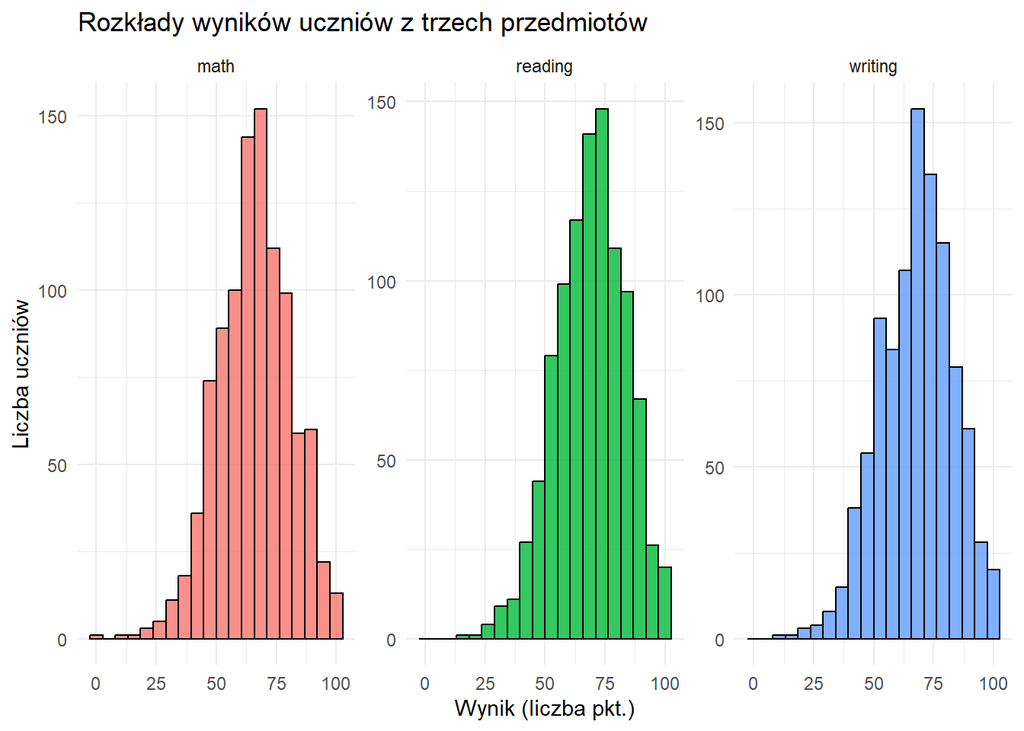

```r
# krok 1 - przeksztalcmy sobie dane
df_pivot_longer <- df %>%
  rename(
    math = "math.score",
    reading = "reading.score",
    writing = "writing.score"
  ) %>%
  pivot_longer(
    cols = c("math", "reading", "writing"), # Użyj już nowych nazw
    names_to = "przedmiot",
    values_to = "wynik"
  )

# krok 2 - wykres
ggplot(df_pivot_longer, aes(x = wynik, fill = przedmiot)) +
  geom_histogram(bins = 20, color = "black", alpha = 0.8) +
  facet_wrap(~ przedmiot, scales = "free_y") +  # 3 panele, po 1 na przedmiot
  labs(
    title = "Rozkłady wyników uczniów z trzech przedmiotów",
    x = "Wynik (liczba pkt.)",
    y = "Liczba uczniów"
  ) +
  theme_minimal() +
  theme(legend.position = "none")
```

**Komentarz:**

Jak widać, rozkłady wyników ze wszystkich trzech przedmiotów zbliżone są kształtem do rozkładu normalnego - charakterystyczny kształt dzwonu z jednym szczytem pośrodku.

## Zadanie 2

Czy istnieje zauważalna różnica w wynikach między uczniami i uczennicami?

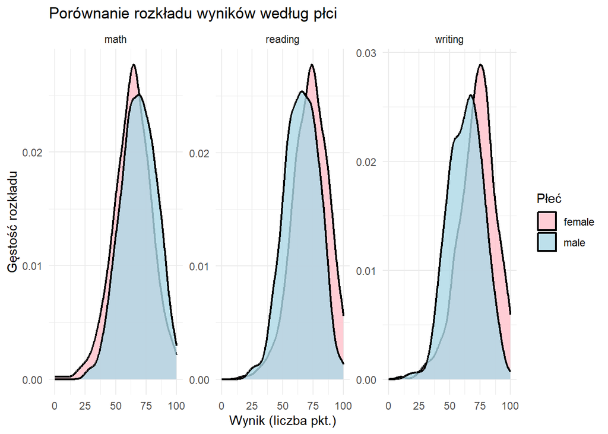

```r
ggplot(df_pivot_longer, aes(x = wynik, fill = gender)) +
  geom_density(alpha = 0.8, linewidth = 0.8) +
  facet_wrap(~ przedmiot, scales = "free_y") + # 3 panele
  scale_fill_manual(values = c("female" = "pink", "male" = "lightblue")) +
  labs(
    title = "Porównanie rozkładu wyników według płci",
    x = "Wynik (liczba pkt.)",
    y = "Gęstość rozkładu",
    fill = "Płeć"
  ) +
  theme_minimal()
```

**Komentarz:**

Dziewczynom idzie generalnie lepiej z czytania oraz pisania, ale chłopakom lepiej idzie matematyka.

## Zadanie 3

Czy uczniowie, którzy ukończyli kurs przygotowawczy, osiągają lepsze wyniki niż pozostali?

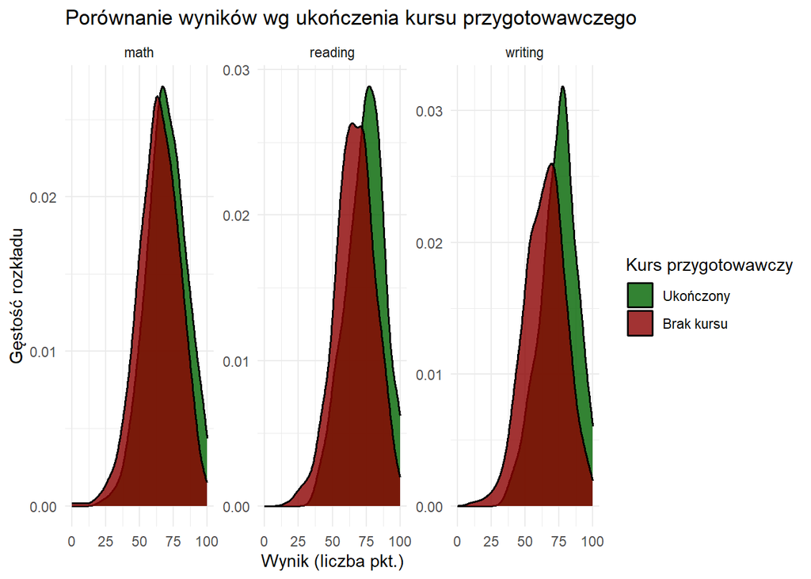

```r
ggplot(df_pivot_longer, aes(x = wynik, fill = test.preparation.course)) +
  geom_density(alpha = 0.8, linewidth = 0.7) +
  facet_wrap(~ przedmiot, scales = "free_y") + # 3 panele
  scale_fill_manual(
    values = c("completed" = "darkgreen", "none" = "darkred"),
    labels = c("completed" = "Ukończony", "none" = "Brak kursu")
  ) +
  labs(
    title = "Porównanie wyników wg ukończenia kursu przygotowawczego",
    x = "Wynik (liczba pkt.)",
    y = "Gęstość rozkładu",
    fill = "Kurs przygotowawczy"
  ) +
  theme_minimal()
```

**Komentarz:**

Uczniowie, którzy ukończyli kurs przygotowawczy, ewidentnie osiągają lepsze wyniki niż pozostali.

## Zadanie 4

Jaki jest związek między poziomem wykształcenia rodziców a średnimi wynikami uczniów?

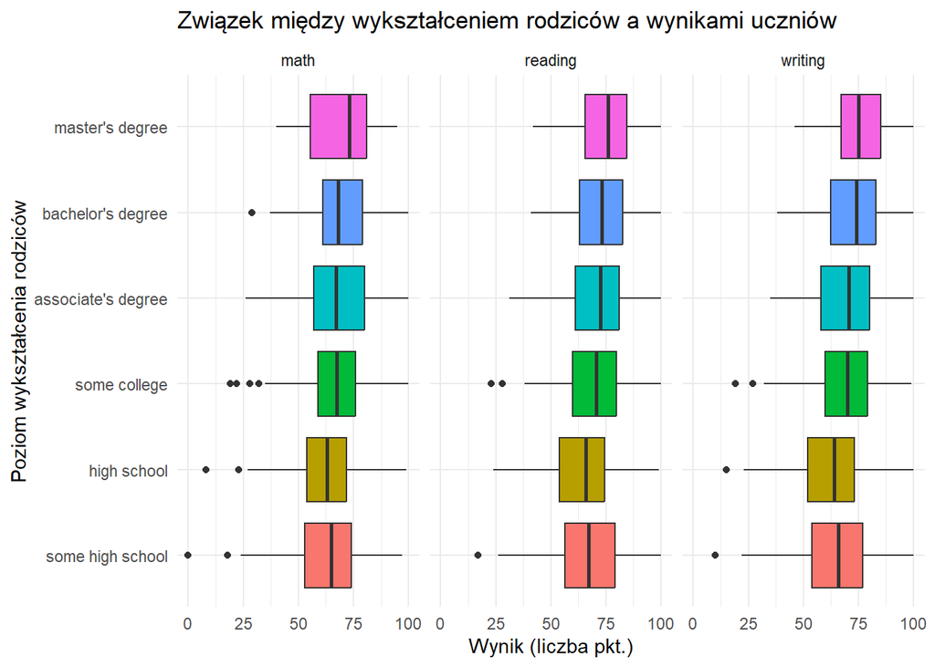

```r
# krok 1 - logiczna kolejność poziomów edukacji rodzicow
poziomy_edukacji <- c(
  "some high school",
  "high school",
  "some college",
  "associate's degree",
  "bachelor's degree",
  "master's degree"
)

# krok 2 - wykres
df_pivot_longer %>%
  mutate(parental.level.of.education = factor(parental.level.of.education, levels = poziomy_edukacji)) %>%
  ggplot(aes(x = parental.level.of.education, y = wynik, fill = parental.level.of.education)) +
  geom_boxplot() +
  facet_wrap(~ przedmiot) + # 3 panele, dla kazdego przedmiotu
  coord_flip() +  # dla czytelnosci
  labs(
    title = "Związek między wykształceniem rodziców a wynikami uczniów",
    x = "Poziom wykształcenia rodziców",
    y = "Wynik (liczba pkt.)"
  ) +
  theme_minimal() +
  theme(legend.position = "none")
```

## Zadanie 5

Czy płeć i wykształcenie rodzica wpływa na wynik z matematyki?

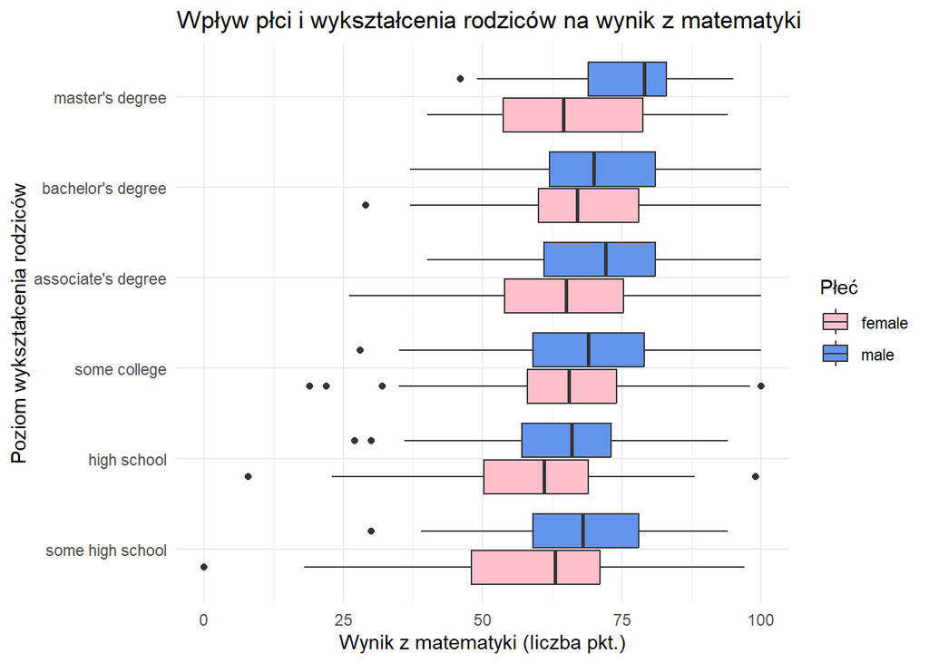

```r
df %>%
  mutate(parental.level.of.education = factor(parental.level.of.education, levels = poziomy_edukacji)) %>%
  ggplot(aes(x = parental.level.of.education, y = math.score, fill = gender)) +
  geom_boxplot(position = position_dodge(width = 0.8)) + # dzieki position_dodge pudelka beda obok siebie
  coord_flip() + # dla czytelnosci
  scale_fill_manual(values = c("female" = "pink", "male" = "cornflowerblue")) +

  labs(
    title = "Wpływ płci i wykształcenia rodziców na wynik z matematyki",
    x = "Poziom wykształcenia rodziców",
    y = "Wynik z matematyki (liczba pkt.)",
    fill = "Płeć"
  ) +
  theme_minimal()
```

## Zadanie 6

Czy istnieje zależność między wynikami z matematyki a wynikami z czytania lub pisania?

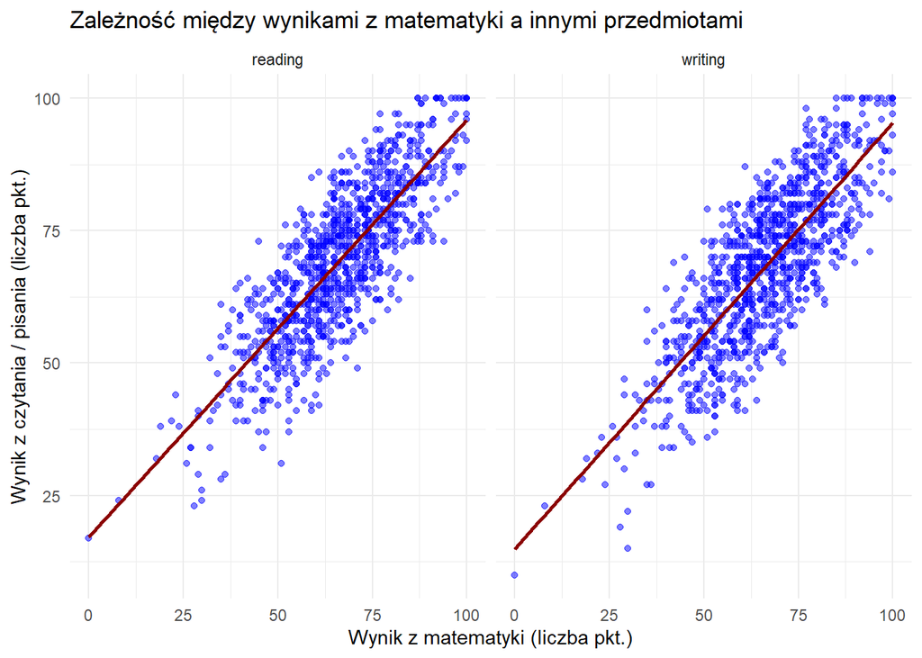

```r
# krok 1 - przygotujmy dane, sklejmy ze soba reading i writing skoro w poleceniu jest "lub"
df_plot_6 <- df %>%
  rename(
    math = "math.score",
    reading = "reading.score",
    writing = "writing.score"
  ) %>%
  pivot_longer(
    cols = c("reading", "writing"),
    names_to = "readingwriting",
    values_to = "readingwriting.score"
  )

# krok 2 - wykresik punktowy
ggplot(df_plot_6, aes(x = math, y = readingwriting.score)) +
  geom_point(alpha = 0.5, color = "blue") +
  geom_smooth(method = "lm", color = "darkred", se = FALSE) + # linia trendu
  facet_wrap(~ readingwriting) +
  labs(
    title = "Zależność między wynikami z matematyki a innymi przedmiotami",
    x = "Wynik z matematyki (liczba pkt.)",
    y = "Wynik z czytania / pisania (liczba pkt.)"
  ) +
  theme_minimal()
```

**Komentarz:** Tak. Uczniowie, którym dobrze idzie z matematyki, mają silną tendencję do osiągania wysokich wyników również z czytania i pisania. Analogicznie, ci, którzy mają niskie wyniki z matmy, mają też przeważnie niskie z pozostałych.